# 1. 分类问题评价指标分析

#### 准确率

准确率=算法分类正确的数据个数/输入算法的数据的个数 当数据不均衡时或者有极偏数据时，准确率不能客观评价算法优劣，举例说明 ：检测1000人是患有癌症，假定我们算法1000人中有3人患病分类错误，准确率得到99.7%，实际上癌症患病率很低，这种预测实际上没有任何预测能力，这时就要考虑评价指标是否有问题了。

由于样本不平衡的问题，导致了得到的高准确率结果含有很大的水分。即如果样本不平衡，准确率就会失效

```python
## accuracy
from sklearn.metrics import accuracy_score
y_pred = [0, 1, 0, 1]
y_true = [0, 1, 1, 0]
print('ACC:',accuracy_score(y_true, y_pred))
```

```
ACC: 0.5
```

#### 混淆矩阵

TN：算法预测为负例（N），实际上也是负例（N）的个数，即算法预测对了（True）

FP：算法预测为正例（P），实际上是负例（N）的个数，即算法预测错了（False）

FN：算法预测为负例（N），实际上是正例（P）的个数，即算法预测错了（False）

TP：算法预测为正例（P），实际上也是正例（P）的个数，即算法预测对了（True）

|  | 预测值 0 | 预测值 1 |
| --- | --- | --- |
| 真实值 0 | TN | FP |
| 真实值 1 | FN | TP |

```python
## 混淆矩阵
import numpy as np
from sklearn.metrics import confusion_matrix
y_pred = [0, 1, 0, 1]
y_true = [0, 1, 1, 0]
print('混淆矩阵:\n',confusion_matrix(y_true, y_pred))
```

```
混淆矩阵:
 [[1 1]
 [1 1]]
```

#### 精准率

$精准率（precision） = \cfrac{TP}{TP+FP}$

精准率就是“预测为正例的那些数据里预测正确的数据个数”。

```python
from sklearn import metrics
y_pred = [0, 1, 0, 1]
y_true = [0, 1, 1, 0]
```

```python
print('Precision',metrics.precision_score(y_true, y_pred))
```

```
Precision 0.5
```

#### 召回率

$召回率（recall） = \cfrac{TP}{TP+FN}$

召回率就是“真实为正例的那些数据里预测正确的数据个数”

在不同的应用场景下，我们的关注点不同，例如，在预测股票的时候，我们更关心精准率，即我们预测升的那些股票里，真的升了有多少，因为那些我们预测升的股票都是我们投钱的。而在预测病患的场景下，我们更关注召回率，即真的患病的那些人里我们预测错了情况应该越少越好，因为真的患病如果没有检测出来，结果其实是很严重的，之前那个无脑的算法，召回率就是 0。

```python
print('Recall',metrics.recall_score(y_true, y_pred))
```

```
Recall 0.5
```

精准率-召回率曲线也叫 PR 曲线

[figure not shown]

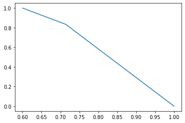

```python
## P-R曲线
import matplotlib.pyplot as plt
from sklearn.metrics import precision_recall_curve
y_pred = [0, 1, 1, 0, 1, 1, 0, 1, 1, 1]
y_true = [0, 1, 1, 0, 1, 0, 1, 1, 0, 1]
precision, recall, thresholds = precision_recall_curve(y_true, y_pred)
plt.plot(precision, recall)
```

#### F1 Score

精准率和召回率是此消彼长的，即精准率高了，召回率就下降，在一些场景下要兼顾精准率和召回率，就有 F1 score。

$F1 = \cfrac{2*precision*recall}{precision+recall}$

F1 score 是精准率和召回率的调和平均数，调和平均数的性质就是，只有当精准率和召回率二者都非常高的时候，它们的调和平均才会高。如果其中之一很低，调和平均就会被拉得接近于那个很低的数

```python
print('F1-score:',metrics.f1_score(y_true, y_pred))
```

```
F1-score: 0.5
```

#### ROC（Receiver Operating Characteristic）

ROC空间将假正例率（FPR）定义为 X 轴，真正例率（TPR）定义为 Y 轴。

横坐标：假正率（False positive rate， FPR），预测为正但实际为负的样本占所有负例样本的比例；

$ FPR = \cfrac{FP}{TN+FP}$

纵坐标：真正率（True positive rate， TPR），这个其实就是召回率，预测为正且实际为正的样本占所有正例样本的比例。

$TPR = \cfrac{TP}{TP+FN}$

[figure not shown]

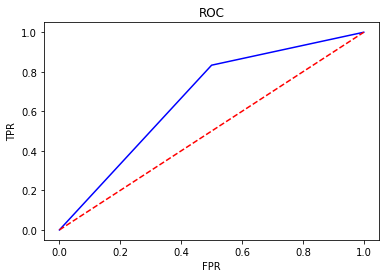

```python
## ROC曲线
from sklearn.metrics import roc_curve
y_pred = [0, 1, 1, 0, 1, 1, 0, 1, 1, 1]
y_true = [0, 1, 1, 0, 1, 0, 1, 1, 0, 1]
FPR,TPR,thresholds=roc_curve(y_true, y_pred)
plt.title('ROC')
plt.plot(FPR, TPR,'b')
plt.plot([0,1],[0,1],'r--')
plt.ylabel('TPR')
plt.xlabel('FPR')
```

#### AUC（Area Under Curve）

AUC 是另一种评价二分类算法的指标，被定义为 ROC 曲线下的面积，显然这个面积的数值不会大于 1。和 F1 score 差不多，都是综合评价精准率和召回率的指标，绘制 ROC 曲线使用了另外两个此消彼长的指标 。

由于 ROC曲线一般都处于y=x这条直线的上方，所以AUC的取值范围在0.5和1之间。AUC越接近1.0，检测方法真实性越 高;等于0.5时，则真实性低，无应用价值。

逻辑回归这样的分类算法而言，通常预测的都是一个概率值，我们会认为设置一个阈值，超过这个阈值，就预测为其中一类，不超过这个阈值，定义为另外一类。于是，不同的阈值就对应了不同的假正率和真正率，于是通过不同的阈值就形成了假正率和真正率序列，它们就可以在直角坐标系上通过描点成为光滑曲线。这个曲线就是 ROC 曲线，ROC 曲线下的面积就是 AUC。

```python
## AUC
import numpy as np
from sklearn.metrics import roc_auc_score
y_true = np.array([0, 0, 1, 1])
y_scores = np.array([0.1, 0.4, 0.35, 0.8])
print('AUC socre:',roc_auc_score(y_true, y_scores))
```

```
AUC socre: 0.75
```

#### KS

K-S曲线将真正例率和假正例率都作为纵轴，横轴则由选定的阈值来充当。

$KS=max(TPR-FPR)$

KS不同代表的不同情况，一般情况KS值越大，模型的区分能力越强，但是也不是越大模型效果就越好，如果 KS过大，模型可能存在异常，所以当KS值过高可能需要检查模型是否过拟合。以下为KS值对应的模型情况， 但此对应不是唯一的，只代表大致趋势。 KS值<0.2,一般认为模型没有区分能力。 KS值[0.2,0.3],模型具有一定区分能力，勉强可以接受 KS值[0.3,0.5],模型具有较强的区分能力。 KS值大于0.75，往往表示模型有异常。

```python
## KS值 在实际操作时往往使用ROC曲线配合求出KS值
from sklearn.metrics import roc_curve
y_pred = [0, 1, 1, 0, 1, 1, 0, 1, 1, 1]
y_true = [0, 1, 1, 0, 1, 0, 1, 1, 1, 1]
FPR,TPR,thresholds=roc_curve(y_true, y_pred)
KS=abs(FPR-TPR).max()
print('KS值：',KS)
```

```
KS值： 0.5238095238095237
```

### 评分卡扩展

评分卡的种类——ABC卡

A卡（Application score card）申请评分卡，贷前，一般可做贷款0-1年的信用分析

B卡（Behavior score card）行为评分卡， 贷中，在申请人有了一定行为后，有了较大数据进行的分析，一般为3-5年

C卡（Collection score card）催收评分卡，贷后，需加入催收后客户反应等属性数据

### FICO信用分

FICO信用分是最常用的一种普通信用分。由于美国三大信用局都使用FICO信用分，每一份信用报告上都附有FICO信用分，以致FICO信用分成为信用分的代名词。该分数是一个[300,850]区间的分数段。

信用评分达到680分以上，贷款方就可以认为借款人的信用卓著，可以毫不迟疑地同意发放款；信用评分低于620分，贷款方或者要求借款人增加担保，或者干脆寻找各种理由拒绝贷款；如果借款人的信用评分介于620-680分之间，贷款方就要作进一步的调查核实，采用其它的信用分析工具，作个案处理。

FICO信用分的评判因素 部分评判标准和影响因素（变量）：

（1）信用偿还历史（占总影响因素的35%）： 各种信用账户的还款记录（信用卡、零售账户 、分期偿还贷款、金融公司账户、抵押贷款）、公开记录及支票存款记录（破产记录、丧失抵押品赎回权记录、法律诉讼事件、留置权记录及判决）、逾期偿还的具体情况（逾期的天数、未偿还的金额、逾期还款的次数和逾期发生时距现在的时间长度等）

（2）信用账户数（占总影响因素的30%）： 分析对于一个客户, 究竟多少个信用账户是足够多的, 从而能够准确反应出客户的还款能力

（3）信用账龄（占总因素的15%）： 该用户信用历史越长，FICO信用分越高。该项因素主要指信用账户的账龄,也包括新开立的信用账户的账龄, 以及平均信用账户账龄。

（4）新开立的账户（占总因素的10%）： 在很短时间内开立多个信用账户的客户具有更高的信用风险, 尤其是那些信用历史不长的人。该类因素包括：新开立的信用账户数、新开立的信用账户账龄、目前的信用申请数量。

（5）在使用的信用类型（占总因素的10%）： 主要分析客户的信用卡账户、零售账户、分期付款账户、金融公司账户和抵押贷款账户的混合使用情况, 具体包括: 持有的信用账户类型和每种类型的信用账户数。

[figure not shown]

# 2.赛题理解

根据给定的数据集，建立模型，预测金融风险

1. id 为贷款清单分配的唯一信用证标识
- loanAmnt 贷款金额 term 贷款期限（year） interestRate 贷款利率 installment 分期付款金额 ：贷款金额越大，贷款期限越短，利率越高，还款难度越大（贷款硬性指标，可参考性强）
1. grade 贷款等级
2. subGrade 贷款等级之子级
- employmentTitle 就业职称 employmentLength 就业年限（年） annualIncome 年收入 ：一般情况 级别越高，就业年数越多，收入相对越多，偿还贷款的能力越强（这些数据有可能造假）
- homeOwnership 借款人在登记时提供的房屋所有权状况 ：拥有房屋，相对偿还贷款的能力越强（提供房屋证明，可信度高）
1. verificationStatus 验证状态
2. issueDate 贷款发放的月份 purpose 借款人在贷款申请时的贷款用途类别 postCode 借款人在贷款申请中提供的邮政编码的前3位数字 regionCode 地区编码 title 借款人提供的贷款名称：个人感觉此类数据对结果影响不大
3. dti 债务收入比
4. delinquency_2years 借款人过去2年信用档案中逾期30天以上的违约事件数
5. ficoRangeLow 借款人在贷款发放时的fico所属的下限范围
6. ficoRangeHigh 借款人在贷款发放时的fico所属的上限范围
7. openAcc 借款人信用档案中未结信用额度的数量
8. pubRec 贬损公共记录的数量
9. pubRecBankruptcies 公开记录清除的数量
10. revolBal 信贷周转余额合计
11. revolUtil 循环额度利用率，或借款人使用的相对于所有可用循环信贷的信贷金额
12. totalAcc 借款人信用档案中当前的信用额度总数
13. initialListStatus 贷款的初始列表状态
14. applicationType 表明贷款是个人申请还是与两个共同借款人的联合申请
15. earliesCreditLine 借款人早报告的信用额度开立的月份
16. policyCode 公开可用的策略代码=1新产品不公开可用的策略代码=2
17. n系列匿名特征 匿名特征n0-n14，为一些贷款人行为计数特征的处理：匿名特征只能通过相关性分析来进行取舍了